# 1870s_Sentiment_Animal_Cruelty

Oliver Hofman

2026-05-25

```r
knitr::opts_chunk$set(echo = TRUE)
library(tidyverse)
library(tidytext)
```

```r
library(ggwordcloud)
library(syuzhet)
```

# Loading the data into R

using Swagger UI, a link is created from the search “dyrplager* py:[1870-79]” in Mediestream

```r
link <- "https://labs.statsbiblioteket.dk/labsapi/api/aviser/export/fields?query=dyrplager%2A%20py%3A%5B1870%20TO%201879%5D&fields=link&fields=recordID&fields=timestamp&fields=pwa&fields=cer&fields=fulltext_org&fields=pageUUID&fields=editionUUID&fields=titleUUID&fields=editionId&fields=familyId&fields=newspaper_page&fields=newspaper_edition&fields=lplace&fields=location_name&fields=location_coordinates&max=-1&structure=header&structure=content&format=CSV"

URLdecode(link)
```

```
## [1] "https://labs.statsbiblioteket.dk/labsapi/api/aviser/export/fields?query=dyrplager* py:[1870 TO 1879]&fields=link&fields=recordID&fields=timestamp&fields=pwa&fields=cer&fields=fulltext_org&fields=pageUUID&fields=editionUUID&fields=titleUUID&fields=editionId&fields=familyId&fields=newspaper_pa…
```

```r
Dyr_1870s <- read.csv(link)
```

# Analysing the datas origin

Here its seen that Copenhagen is still in a clear lead, but Aarhus has made a big jump from the last one. “Nationaltidende” takes the lead for most mentions, with berlingske falling behind.

```r
Dyr_1870s %>%
  count(lplace, sort = TRUE)
```

```
##              lplace   n
## 1         København 774
## 2            Aarhus 123
## 3  Nykøbing Falster  99
## 4              Køge  75
## 5           Horsens  73
## 6           Aalborg  72
## 7          Ringsted  72
## 8         Svendborg  68
## 9            Viborg  62
## 10         Slagelse  56
## 11            Rønne  53
## 12         Hillerød  49
## 13        Silkeborg  49
## 14           Odense  46
```

[output cut: 28 more lines]

```r
Dyr_1870s %>%
  count(familyId, sort = TRUE)
```

```
##                        familyId   n
## 1               nationaltidende 152
## 2               dagstelegraphen 134
## 3    morgenavisenjyllandsposten  87
## 4          aalborgstiftstidende  72
## 5             dagensnyheder1868  72
## 6             berlingsketidende  70
## 7              faedrelandet1834  70
## 8              morgenbladet1873  69
## 9       dagbladetkoebenhavn1851  68
## 10           oestsjaellandsavis  68
## 11              folketsavis1860  67
## 12                      aktuelt  64
## 13          viborgstiftstidende  58
## 14  lollandfalstersfolketidende  54
```

[output cut: 48 more lines]

#Textmining Here the articles are divided up into singular words and then edited by using a list of stopwords pertaining to especially 1800s danish.

```r
Dyr_1870s_tidy <- Dyr_1870s %>%
  unnest_tokens(word, fulltext_org)

stopwords_1800s <- read_csv("https://gist.githubusercontent.com/maxodsbjerg/1537cf14c3d46b3d30caa5d99f8758e9/raw/9f044a38505334f035be111c9a3f654a24418f6d/stopord_18_clean.csv")
Dyr_1870s_wStopwords<- Dyr_1870s_tidy %>%
  anti_join(stopwords_1800s) %>%
  count(word, sort = TRUE)
```

#Removing numerals and creating a top 100 Here numbers are filtered out, as to only get actual words that can be analysed. Then its put into a top 100 of most mentions

```r
Dyr_1870s_nonum <- Dyr_1870s_wStopwords %>%
filter(!str_detect(word, "[0-9]"))

 Dyr_1870s_top100 <- head(Dyr_1870s_nonum, 100)

 Dyr_1870s_top100
```

```
##           word    n
## 1           kr 3524
## 2   dyrplageri 2355
## 3           vg 1653
## 4         selv 1564
## 5          faa 1500
## 6         idet 1495
## 7        siden 1449
## 8        anden 1435
## 9        mange 1411
## 10         dyr 1395
## 11          os 1393
## 12         vel 1352
## 13      maatte 1286
## 14        lige 1272
```

[output cut: 86 more lines]

#Wordcloud by creating a wordcloud with the top 100, its made easier to visualize whats mentioned the most.

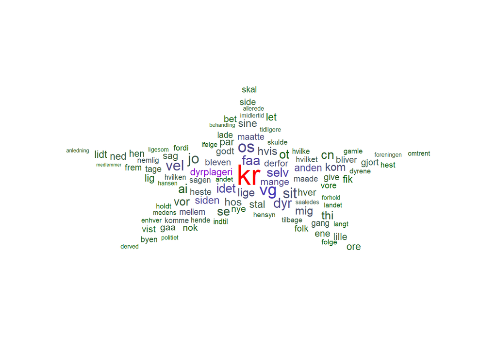

```r
ggplot(data = Dyr_1870s_top100, aes(label = word, size = n)) +
  geom_text_wordcloud_area(aes(color = n), shape = "star") +
  scale_size_area(max_size = 12) +
  scale_color_gradientn(colors = c("darkgreen","blue","red")) +
  theme_minimal()
```

#Sentiment analysis here the text a once again edited with the stopwords, and then joined together as to get a overall sentiment score from the articles.

```r
fulltext_tidy_recordID <- Dyr_1870s_tidy %>%
  anti_join(stopwords_1800s, by = c("word" = "word")) %>%
  group_by(recordID) %>%
  summarise(fulltext_clean = paste(word, collapse = " "), .groups = "drop")

sentiment_text_recordID <- fulltext_tidy_recordID %>%
  mutate(
    fulltext_sentiment = map_dbl(
      fulltext_clean,
      function(x) get_sentiment(x, method = "afinn")
    )
  )
sentiment_by_record_1870s <- sentiment_text_recordID %>%
  group_by(recordID) %>%
  summarise(
    mean_sentiment = mean(fulltext_sentiment, na.rm = TRUE),
    n = n()
  )
```

#Visualizing the Sentiment here the articles sentiment score is plotted into a histogram to better visualize the spread of sentiment across all the articles

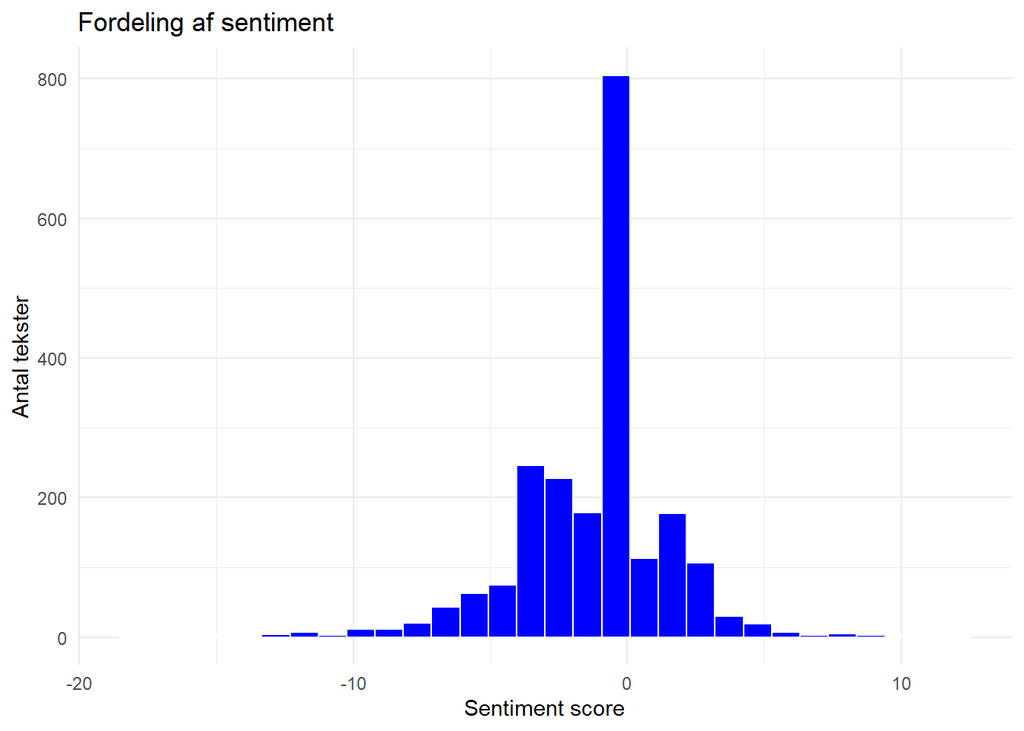

```r
library(ggplot2)

ggplot(sentiment_by_record_1870s,
       aes(x = mean_sentiment)) +
  geom_histogram(bins = 30,
                 fill = "Blue",
                 color = "white") +
  theme_minimal() +
  labs(
    title = "Fordeling af sentiment",
    x = "Sentiment score",
    y = "Antal tekster"
  )
```

#Average Sentiment Score here a average of the sentiment is calculated

```r
mean(sentiment_by_record_1870s$mean_sentiment,
     na.rm = TRUE)
```

```
## [1] -0.9093851
```

#Categorizing the sentiment by dividing all the articles into 3 Categories, “Positiv”, “Negativ” and “Neutral” and counting how many of the articles land into each categories

```r
sentiment_CAT_1870s <- sentiment_by_record_1870s %>%
  mutate(sentiment_category = case_when(
    mean_sentiment > 0 ~ "Positiv",
    mean_sentiment < 0 ~ "Negativ",
    TRUE ~ "Neutral"
  ))

sentiment_CAT_1870s %>%
  count(sentiment_category)
```

```
## # A tibble: 3 × 2
##   sentiment_category     n
##   <chr>              <int>
## 1 Negativ              893
## 2 Neutral              805
## 3 Positiv              465
```